# Optimal Treatment Analysis

## Outcome Variable

**Outcome Variable:** whz

## Predictor Variables

**Intervention Variable:** mwtkg

**Adjustment Set:**

- arm
- W_mage
- meducyrs
- feducyrs
- single
- brthmon
- delta_W_mage
- delta_meducyrs
- delta_feducyrs
- delta_single
- delta_brthmon

## Stratifying Variables

The analysis was stratified on these variable(s):

- agecat
- studyid
- country

## Data Summary

| agecat | studyid | country | mwtkg | n_cell | n |
| --- | --- | --- | --- | --- | --- |
| Birth | ki0047075b-MAL-ED | BANGLADESH | >=58 kg | 46 | 233 |
| Birth | ki0047075b-MAL-ED | BANGLADESH | <52 kg | 144 | 233 |
| Birth | ki0047075b-MAL-ED | BANGLADESH | [52-58) kg | 43 | 233 |
| Birth | ki0047075b-MAL-ED | BRAZIL | >=58 kg | 117 | 176 |
| Birth | ki0047075b-MAL-ED | BRAZIL | <52 kg | 31 | 176 |
| Birth | ki0047075b-MAL-ED | BRAZIL | [52-58) kg | 28 | 176 |
| Birth | ki0047075b-MAL-ED | INDIA | >=58 kg | 36 | 195 |
| Birth | ki0047075b-MAL-ED | INDIA | <52 kg | 121 | 195 |
| Birth | ki0047075b-MAL-ED | INDIA | [52-58) kg | 38 | 195 |
| Birth | ki0047075b-MAL-ED | NEPAL | >=58 kg | 56 | 167 |
| Birth | ki0047075b-MAL-ED | NEPAL | <52 kg | 48 | 167 |
| Birth | ki0047075b-MAL-ED | NEPAL | [52-58) kg | 63 | 167 |
| Birth | ki0047075b-MAL-ED | PERU | >=58 kg | 97 | 269 |
| Birth | ki0047075b-MAL-ED | PERU | <52 kg | 104 | 269 |
| Birth | ki0047075b-MAL-ED | PERU | [52-58) kg | 68 | 269 |
| Birth | ki0047075b-MAL-ED | SOUTH AFRICA | >=58 kg | 165 | 226 |
| Birth | ki0047075b-MAL-ED | SOUTH AFRICA | <52 kg | 23 | 226 |
| Birth | ki0047075b-MAL-ED | SOUTH AFRICA | [52-58) kg | 38 | 226 |
| Birth | ki0047075b-MAL-ED | TANZANIA, UNITED REPUBLIC OF | >=58 kg | 51 | 116 |
| Birth | ki0047075b-MAL-ED | TANZANIA, UNITED REPUBLIC OF | <52 kg | 37 | 116 |
| Birth | ki0047075b-MAL-ED | TANZANIA, UNITED REPUBLIC OF | [52-58) kg | 28 | 116 |
| Birth | ki1000304b-SAS-CompFeed | INDIA | >=58 kg | 2 | 60 |
| Birth | ki1000304b-SAS-CompFeed | INDIA | <52 kg | 50 | 60 |
| Birth | ki1000304b-SAS-CompFeed | INDIA | [52-58) kg | 8 | 60 |
| Birth | ki1017093-NIH-Birth | BANGLADESH | >=58 kg | 2 | 28 |
| Birth | ki1017093-NIH-Birth | BANGLADESH | <52 kg | 23 | 28 |
| Birth | ki1017093-NIH-Birth | BANGLADESH | [52-58) kg | 3 | 28 |
| Birth | ki1017093c-NIH-Crypto | BANGLADESH | >=58 kg | 4 | 23 |
| Birth | ki1017093c-NIH-Crypto | BANGLADESH | <52 kg | 17 | 23 |
| Birth | ki1017093c-NIH-Crypto | BANGLADESH | [52-58) kg | 2 | 23 |

[output cut: 93 more lines]

The following strata were considered:

- agecat: 24 months, studyid: ki0047075b-MAL-ED, country: BANGLADESH
- agecat: 24 months, studyid: ki0047075b-MAL-ED, country: BRAZIL
- agecat: 24 months, studyid: ki0047075b-MAL-ED, country: INDIA
- agecat: 24 months, studyid: ki0047075b-MAL-ED, country: NEPAL
- agecat: 24 months, studyid: ki0047075b-MAL-ED, country: PERU
- agecat: 24 months, studyid: ki0047075b-MAL-ED, country: SOUTH AFRICA
- agecat: 24 months, studyid: ki0047075b-MAL-ED, country: TANZANIA, UNITED REPUBLIC OF
- agecat: 24 months, studyid: ki1017093-NIH-Birth, country: BANGLADESH
- agecat: 24 months, studyid: ki1017093b-PROVIDE, country: BANGLADESH
- agecat: 24 months, studyid: ki1017093c-NIH-Crypto, country: BANGLADESH
- agecat: 24 months, studyid: ki1066203-TanzaniaChild2, country: TANZANIA, UNITED REPUBLIC OF
- agecat: 24 months, studyid: ki1119695-PROBIT, country: BELARUS
- agecat: 24 months, studyid: ki1126311-ZVITAMBO, country: ZIMBABWE
- agecat: 24 months, studyid: ki1148112-LCNI-5, country: MALAWI
- agecat: 6 months, studyid: ki0047075b-MAL-ED, country: BANGLADESH
- agecat: 6 months, studyid: ki0047075b-MAL-ED, country: BRAZIL
- agecat: 6 months, studyid: ki0047075b-MAL-ED, country: INDIA
- agecat: 6 months, studyid: ki0047075b-MAL-ED, country: NEPAL
- agecat: 6 months, studyid: ki0047075b-MAL-ED, country: PERU
- agecat: 6 months, studyid: ki0047075b-MAL-ED, country: SOUTH AFRICA
- agecat: 6 months, studyid: ki0047075b-MAL-ED, country: TANZANIA, UNITED REPUBLIC OF
- agecat: 6 months, studyid: ki1000304b-SAS-CompFeed, country: INDIA
- agecat: 6 months, studyid: ki1017093-NIH-Birth, country: BANGLADESH
- agecat: 6 months, studyid: ki1017093b-PROVIDE, country: BANGLADESH
- agecat: 6 months, studyid: ki1017093c-NIH-Crypto, country: BANGLADESH
- agecat: 6 months, studyid: ki1066203-TanzaniaChild2, country: TANZANIA, UNITED REPUBLIC OF
- agecat: 6 months, studyid: ki1119695-PROBIT, country: BELARUS
- agecat: 6 months, studyid: ki1126311-ZVITAMBO, country: ZIMBABWE
- agecat: 6 months, studyid: ki1148112-LCNI-5, country: MALAWI
- agecat: Birth, studyid: ki0047075b-MAL-ED, country: BANGLADESH
- agecat: Birth, studyid: ki0047075b-MAL-ED, country: BRAZIL
- agecat: Birth, studyid: ki0047075b-MAL-ED, country: INDIA
- agecat: Birth, studyid: ki0047075b-MAL-ED, country: NEPAL
- agecat: Birth, studyid: ki0047075b-MAL-ED, country: PERU
- agecat: Birth, studyid: ki0047075b-MAL-ED, country: SOUTH AFRICA
- agecat: Birth, studyid: ki0047075b-MAL-ED, country: TANZANIA, UNITED REPUBLIC OF
- agecat: Birth, studyid: ki1000304b-SAS-CompFeed, country: INDIA
- agecat: Birth, studyid: ki1017093-NIH-Birth, country: BANGLADESH
- agecat: Birth, studyid: ki1017093c-NIH-Crypto, country: BANGLADESH
- agecat: Birth, studyid: ki1119695-PROBIT, country: BELARUS
- agecat: Birth, studyid: ki1126311-ZVITAMBO, country: ZIMBABWE

### Dropped Strata

Some strata were dropped due to rare outcomes:

- agecat: Birth, studyid: ki1000304b-SAS-CompFeed, country: INDIA
- agecat: Birth, studyid: ki1017093-NIH-Birth, country: BANGLADESH
- agecat: Birth, studyid: ki1017093c-NIH-Crypto, country: BANGLADESH
- agecat: 24 months, studyid: ki1066203-TanzaniaChild2, country: TANZANIA, UNITED REPUBLIC OF

## Methods Detail

We’re interested in the causal parameters $E[Y_a]$ for all values of $a \in \mathcal{A}$. These parameters represent the mean outcome if, possibly contrary to fact, we intervened to set all units to have $A=a$. Under the randomization and positivity assumptions, these are identified by the statistical parameters $\psi_a=E_W[E_{Y|A,W}(Y|A=a,W)]$. In addition, we’re interested in the mean of $Y$, $E[Y]$ under no intervention (the observed mean). We will estimate these parameters by using SuperLearner to fit the relevant likelihood factors – $E_{Y|A,W}(Y|A=a,W)$ and $p(A=a|W)$, and then updating our likelihood fit using a joint TMLE.

For unadjusted analyses ($W=\{\}$), initial likelihoods were estimated using Lrnr_glm to estimate the simple $E(Y|A)$ and Lrnr_mean to estimate $p(A)$. For adjusted analyses, a small library containing Lrnr_glmnet, Lrnr_xgboost, and Lrnr_mean was used.

Having estimated these parameters, we will then use the delta method to estimate relative risks and attributable risks relative to a prespecified baseline level of $A$.

# Results Detail

## Results Plots

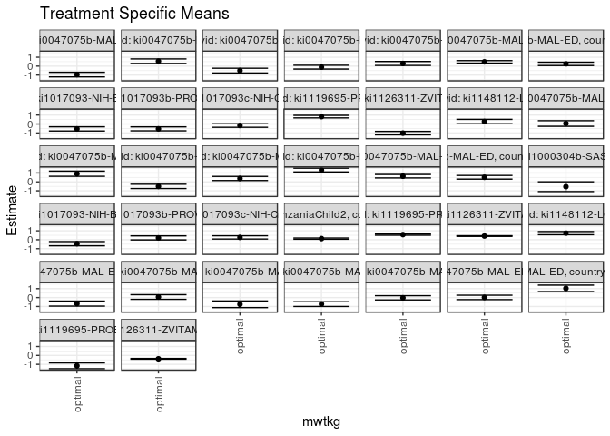

## Results Table

### Parameter: TSM

| agecat | studyid | country | intervention_level | baseline_level | estimate | ci_lower | ci_upper |
| --- | --- | --- | --- | --- | --- | --- | --- |
| Birth | ki0047075b-MAL-ED | BANGLADESH | optimal | observed | -0.6765929 | -0.9588010 | -0.3943848 |
| Birth | ki0047075b-MAL-ED | BRAZIL | optimal | observed | 0.0617957 | -0.1970824 | 0.3206739 |
| Birth | ki0047075b-MAL-ED | INDIA | optimal | observed | -0.7553640 | -1.1281472 | -0.3825808 |
| Birth | ki0047075b-MAL-ED | NEPAL | optimal | observed | -0.7348497 | -0.9985929 | -0.4711064 |
| Birth | ki0047075b-MAL-ED | PERU | optimal | observed | -0.0286917 | -0.2666679 | 0.2092844 |
| Birth | ki0047075b-MAL-ED | SOUTH AFRICA | optimal | observed | 0.0156703 | -0.2341333 | 0.2654739 |
| Birth | ki0047075b-MAL-ED | TANZANIA, UNITED REPUBLIC OF | optimal | observed | 1.0310515 | 0.6689507 | 1.3931523 |
| Birth | ki1119695-PROBIT | BELARUS | optimal | observed | -1.1647668 | -1.4928012 | -0.8367324 |
| Birth | ki1126311-ZVITAMBO | ZIMBABWE | optimal | observed | -0.3787010 | -0.4202770 | -0.3371250 |
| 6 months | ki0047075b-MAL-ED | BANGLADESH | optimal | observed | 0.0578494 | -0.2568244 | 0.3725233 |
| 6 months | ki0047075b-MAL-ED | BRAZIL | optimal | observed | 0.9137419 | 0.6221351 | 1.2053487 |
| 6 months | ki0047075b-MAL-ED | INDIA | optimal | observed | -0.5047959 | -0.7469774 | -0.2626143 |
| 6 months | ki0047075b-MAL-ED | NEPAL | optimal | observed | 0.3809448 | 0.1488055 | 0.6130841 |
| 6 months | ki0047075b-MAL-ED | PERU | optimal | observed | 1.3219119 | 1.1108907 | 1.5329330 |
| 6 months | ki0047075b-MAL-ED | SOUTH AFRICA | optimal | observed | 0.6356368 | 0.4398022 | 0.8314714 |
| 6 months | ki0047075b-MAL-ED | TANZANIA, UNITED REPUBLIC OF | optimal | observed | 0.5156621 | 0.3098342 | 0.7214900 |
| 6 months | ki1000304b-SAS-CompFeed | INDIA | optimal | observed | -0.5390796 | -1.0833421 | 0.0051829 |
| 6 months | ki1017093-NIH-Birth | BANGLADESH | optimal | observed | -0.4433483 | -0.6784717 | -0.2082248 |
| 6 months | ki1017093b-PROVIDE | BANGLADESH | optimal | observed | 0.2064741 | -0.0205349 | 0.4334831 |
| 6 months | ki1017093c-NIH-Crypto | BANGLADESH | optimal | observed | 0.2608312 | 0.0795749 | 0.4420875 |
| 6 months | ki1066203-TanzaniaChild2 | TANZANIA, UNITED REPUBLIC OF | optimal | observed | 0.1266101 | 0.0591155 | 0.1941047 |
| 6 months | ki1119695-PROBIT | BELARUS | optimal | observed | 0.5764788 | 0.5090255 | 0.6439321 |
| 6 months | ki1126311-ZVITAMBO | ZIMBABWE | optimal | observed | 0.4160265 | 0.3795737 | 0.4524794 |
| 6 months | ki1148112-LCNI-5 | MALAWI | optimal | observed | 0.7376320 | 0.5585580 | 0.9167060 |
| 24 months | ki0047075b-MAL-ED | BANGLADESH | optimal | observed | -0.9456671 | -1.2051326 | -0.6862015 |
| 24 months | ki0047075b-MAL-ED | BRAZIL | optimal | observed | 0.5535714 | 0.2961067 | 0.8110361 |
| 24 months | ki0047075b-MAL-ED | INDIA | optimal | observed | -0.4988693 | -0.7638142 | -0.2339244 |
| 24 months | ki0047075b-MAL-ED | NEPAL | optimal | observed | -0.1147886 | -0.3268027 | 0.0972255 |
| 24 months | ki0047075b-MAL-ED | PERU | optimal | observed | 0.2974194 | 0.0743223 | 0.5205165 |
| 24 months | ki0047075b-MAL-ED | SOUTH AFRICA | optimal | observed | 0.4807639 | 0.3418269 | 0.6197009 |
| 24 months | ki0047075b-MAL-ED | TANZANIA, UNITED REPUBLIC OF | optimal | observed | 0.2547252 | 0.0652518 | 0.4441985 |
| 24 months | ki1017093-NIH-Birth | BANGLADESH | optimal | observed | -0.5484702 | -0.7846375 | -0.3123029 |
| 24 months | ki1017093b-PROVIDE | BANGLADESH | optimal | observed | -0.5410267 | -0.7649399 | -0.3171136 |
| 24 months | ki1017093c-NIH-Crypto | BANGLADESH | optimal | observed | -0.1682082 | -0.3670448 | 0.0306283 |
| 24 months | ki1119695-PROBIT | BELARUS | optimal | observed | 0.8266910 | 0.6821164 | 0.9712655 |
| 24 months | ki1126311-ZVITAMBO | ZIMBABWE | optimal | observed | -1.0226530 | -1.2186174 | -0.8266886 |
| 24 months | ki1148112-LCNI-5 | MALAWI | optimal | observed | 0.2769115 | 0.0312234 | 0.5225995 |

### Parameter: E(Y)

| agecat | studyid | country | intervention_level | baseline_level | estimate | ci_lower | ci_upper |
| --- | --- | --- | --- | --- | --- | --- | --- |
| Birth | ki0047075b-MAL-ED | BANGLADESH | observed | observed | -0.9724464 | -1.1091046 | -0.8357881 |
| Birth | ki0047075b-MAL-ED | BRAZIL | observed | observed | 0.3832386 | 0.2044597 | 0.5620175 |
| Birth | ki0047075b-MAL-ED | INDIA | observed | observed | -1.0698974 | -1.2115847 | -0.9282102 |
| Birth | ki0047075b-MAL-ED | NEPAL | observed | observed | -0.9126946 | -1.0520834 | -0.7733058 |
| Birth | ki0047075b-MAL-ED | PERU | observed | observed | -0.0660967 | -0.1789362 | 0.0467429 |
| Birth | ki0047075b-MAL-ED | SOUTH AFRICA | observed | observed | -0.0346018 | -0.1831486 | 0.1139451 |
| Birth | ki0047075b-MAL-ED | TANZANIA, UNITED REPUBLIC OF | observed | observed | 0.7950000 | 0.5947353 | 0.9952647 |
| Birth | ki1119695-PROBIT | BELARUS | observed | observed | -1.1838417 | -1.5179872 | -0.8496961 |
| Birth | ki1126311-ZVITAMBO | ZIMBABWE | observed | observed | -0.4819806 | -0.5108811 | -0.4530800 |
| 6 months | ki0047075b-MAL-ED | BANGLADESH | observed | observed | -0.1397960 | -0.2688682 | -0.0107238 |
| 6 months | ki0047075b-MAL-ED | BRAZIL | observed | observed | 0.9644952 | 0.7999744 | 1.1290160 |
| 6 months | ki0047075b-MAL-ED | INDIA | observed | observed | -0.6987943 | -0.8241325 | -0.5734561 |
| 6 months | ki0047075b-MAL-ED | NEPAL | observed | observed | 0.1110452 | -0.0202712 | 0.2423616 |
| 6 months | ki0047075b-MAL-ED | PERU | observed | observed | 1.0563787 | 0.9342938 | 1.1784635 |
| 6 months | ki0047075b-MAL-ED | SOUTH AFRICA | observed | observed | 0.5290428 | 0.3750394 | 0.6830463 |
| 6 months | ki0047075b-MAL-ED | TANZANIA, UNITED REPUBLIC OF | observed | observed | 0.5170513 | 0.3872178 | 0.6468847 |
| 6 months | ki1000304b-SAS-CompFeed | INDIA | observed | observed | -0.8006585 | -0.9951895 | -0.6061275 |
| 6 months | ki1017093-NIH-Birth | BANGLADESH | observed | observed | -0.4389101 | -0.5279432 | -0.3498771 |
| 6 months | ki1017093b-PROVIDE | BANGLADESH | observed | observed | -0.2079891 | -0.2925599 | -0.1234183 |
| 6 months | ki1017093c-NIH-Crypto | BANGLADESH | observed | observed | 0.0297622 | -0.0491685 | 0.1086930 |
| 6 months | ki1066203-TanzaniaChild2 | TANZANIA, UNITED REPUBLIC OF | observed | observed | 0.0780261 | 0.0247830 | 0.1312691 |
| 6 months | ki1119695-PROBIT | BELARUS | observed | observed | 0.5806095 | 0.5057299 | 0.6554891 |
| 6 months | ki1126311-ZVITAMBO | ZIMBABWE | observed | observed | 0.2953392 | 0.2687669 | 0.3219114 |
| 6 months | ki1148112-LCNI-5 | MALAWI | observed | observed | 0.4518399 | 0.3806212 | 0.5230586 |
| 24 months | ki0047075b-MAL-ED | BANGLADESH | observed | observed | -0.8208255 | -0.9429246 | -0.6987264 |
| 24 months | ki0047075b-MAL-ED | BRAZIL | observed | observed | 0.4282738 | 0.2252365 | 0.6313111 |
| 24 months | ki0047075b-MAL-ED | INDIA | observed | observed | -0.9525664 | -1.0684455 | -0.8366872 |
| 24 months | ki0047075b-MAL-ED | NEPAL | observed | observed | -0.3764474 | -0.4898516 | -0.2630431 |
| 24 months | ki0047075b-MAL-ED | PERU | observed | observed | 0.1199005 | -0.0000331 | 0.2398341 |
| 24 months | ki0047075b-MAL-ED | SOUTH AFRICA | observed | observed | 0.4096154 | 0.2902946 | 0.5289362 |
| 24 months | ki0047075b-MAL-ED | TANZANIA, UNITED REPUBLIC OF | observed | observed | 0.0500935 | -0.0748234 | 0.1750103 |
| 24 months | ki1017093-NIH-Birth | BANGLADESH | observed | observed | -0.9115790 | -1.0095022 | -0.8136559 |
| 24 months | ki1017093b-PROVIDE | BANGLADESH | observed | observed | -0.8864991 | -0.9695215 | -0.8034768 |
| 24 months | ki1017093c-NIH-Crypto | BANGLADESH | observed | observed | -0.6103502 | -0.7050157 | -0.5156847 |
| 24 months | ki1119695-PROBIT | BELARUS | observed | observed | 0.8080520 | 0.6569945 | 0.9591095 |
| 24 months | ki1126311-ZVITAMBO | ZIMBABWE | observed | observed | -1.1865133 | -1.2873598 | -1.0856668 |
| 24 months | ki1148112-LCNI-5 | MALAWI | observed | observed | -0.0467082 | -0.1287046 | 0.0352882 |

### Parameter: PAR

| agecat | studyid | country | intervention_level | baseline_level | estimate | ci_lower | ci_upper |
| --- | --- | --- | --- | --- | --- | --- | --- |
| Birth | ki0047075b-MAL-ED | BANGLADESH | optimal | observed | -0.2958534 | -0.5566995 | -0.0350073 |
| Birth | ki0047075b-MAL-ED | BRAZIL | optimal | observed | 0.3214429 | 0.1121547 | 0.5307311 |
| Birth | ki0047075b-MAL-ED | INDIA | optimal | observed | -0.3145334 | -0.6485545 | 0.0194876 |
| Birth | ki0047075b-MAL-ED | NEPAL | optimal | observed | -0.1778450 | -0.3831428 | 0.0274529 |
| Birth | ki0047075b-MAL-ED | PERU | optimal | observed | -0.0374049 | -0.2338285 | 0.1590186 |
| Birth | ki0047075b-MAL-ED | SOUTH AFRICA | optimal | observed | -0.0502720 | -0.2608306 | 0.1602865 |
| Birth | ki0047075b-MAL-ED | TANZANIA, UNITED REPUBLIC OF | optimal | observed | -0.2360515 | -0.5392872 | 0.0671842 |
| Birth | ki1119695-PROBIT | BELARUS | optimal | observed | -0.0190749 | -0.0454354 | 0.0072856 |
| Birth | ki1126311-ZVITAMBO | ZIMBABWE | optimal | observed | -0.1032796 | -0.1329160 | -0.0736432 |
| 6 months | ki0047075b-MAL-ED | BANGLADESH | optimal | observed | -0.1976454 | -0.4854149 | 0.0901240 |
| 6 months | ki0047075b-MAL-ED | BRAZIL | optimal | observed | 0.0507533 | -0.1745443 | 0.2760509 |
| 6 months | ki0047075b-MAL-ED | INDIA | optimal | observed | -0.1939985 | -0.4252393 | 0.0372424 |
| 6 months | ki0047075b-MAL-ED | NEPAL | optimal | observed | -0.2698996 | -0.4577811 | -0.0820181 |
| 6 months | ki0047075b-MAL-ED | PERU | optimal | observed | -0.2655332 | -0.4349589 | -0.0961075 |
| 6 months | ki0047075b-MAL-ED | SOUTH AFRICA | optimal | observed | -0.1065939 | -0.2344980 | 0.0213102 |
| 6 months | ki0047075b-MAL-ED | TANZANIA, UNITED REPUBLIC OF | optimal | observed | 0.0013892 | -0.1801299 | 0.1829083 |
| 6 months | ki1000304b-SAS-CompFeed | INDIA | optimal | observed | -0.2615789 | -0.6624178 | 0.1392600 |
| 6 months | ki1017093-NIH-Birth | BANGLADESH | optimal | observed | 0.0044381 | -0.2155391 | 0.2244153 |
| 6 months | ki1017093b-PROVIDE | BANGLADESH | optimal | observed | -0.4144632 | -0.6183604 | -0.2105659 |
| 6 months | ki1017093c-NIH-Crypto | BANGLADESH | optimal | observed | -0.2310689 | -0.3872223 | -0.0749156 |
| 6 months | ki1066203-TanzaniaChild2 | TANZANIA, UNITED REPUBLIC OF | optimal | observed | -0.0485840 | -0.0900857 | -0.0070823 |
| 6 months | ki1119695-PROBIT | BELARUS | optimal | observed | 0.0041307 | -0.0265016 | 0.0347630 |
| 6 months | ki1126311-ZVITAMBO | ZIMBABWE | optimal | observed | -0.1206874 | -0.1466591 | -0.0947157 |
| 6 months | ki1148112-LCNI-5 | MALAWI | optimal | observed | -0.2857921 | -0.4553154 | -0.1162688 |
| 24 months | ki0047075b-MAL-ED | BANGLADESH | optimal | observed | 0.1248416 | -0.1153764 | 0.3650596 |
| 24 months | ki0047075b-MAL-ED | BRAZIL | optimal | observed | -0.1252976 | -0.2771820 | 0.0265868 |
| 24 months | ki0047075b-MAL-ED | INDIA | optimal | observed | -0.4536971 | -0.6989718 | -0.2084224 |
| 24 months | ki0047075b-MAL-ED | NEPAL | optimal | observed | -0.2616588 | -0.4290384 | -0.0942791 |
| 24 months | ki0047075b-MAL-ED | PERU | optimal | observed | -0.1775189 | -0.3697492 | 0.0147114 |
| 24 months | ki0047075b-MAL-ED | SOUTH AFRICA | optimal | observed | -0.0711485 | -0.1494726 | 0.0071756 |
| 24 months | ki0047075b-MAL-ED | TANZANIA, UNITED REPUBLIC OF | optimal | observed | -0.2046317 | -0.3650241 | -0.0442393 |
| 24 months | ki1017093-NIH-Birth | BANGLADESH | optimal | observed | -0.3631088 | -0.5887358 | -0.1374818 |
| 24 months | ki1017093b-PROVIDE | BANGLADESH | optimal | observed | -0.3454724 | -0.5448905 | -0.1460543 |
| 24 months | ki1017093c-NIH-Crypto | BANGLADESH | optimal | observed | -0.4421420 | -0.6155874 | -0.2686966 |
| 24 months | ki1119695-PROBIT | BELARUS | optimal | observed | -0.0186389 | -0.0781144 | 0.0408366 |
| 24 months | ki1126311-ZVITAMBO | ZIMBABWE | optimal | observed | -0.1638603 | -0.3357339 | 0.0080133 |
| 24 months | ki1148112-LCNI-5 | MALAWI | optimal | observed | -0.3236197 | -0.5507970 | -0.0964423 |